# Classifying Correctness of Barbel Lifts Using Monitoring Device Data

Amir Manafpour

5/13/2020

## Executive Summary

This study develops and evaluates a random forest prediction model to predit if an individual is performing barbell lifts correctly or incorrectly. The dataset was obtained from this source: http://groupware.les.inf.puc-rio.br/har and it consists of data from accelerometers on the belt, forearm, arm, and dumbell of 6 participants. At the end of the study a test set of 20 samples were utilized to predict the action class and to answer quiz questions for the Practical Machine Learning course project on Coursera.

## Exploratory Analysis

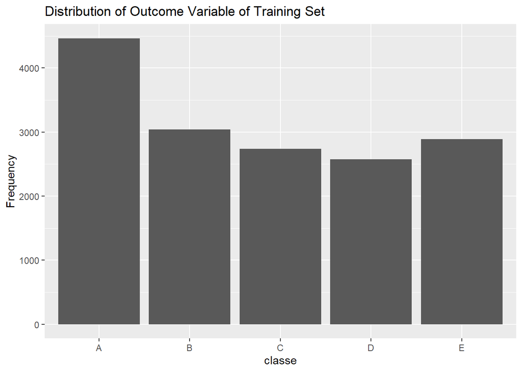

```r
df <- read.csv(url("https://d396qusza40orc.cloudfront.net/predmachlearn/pml-training.csv"))

# Split available data into 80% training and 20% testing sets
set.seed(3234)
inTrain <- createDataPartition(y=df$classe, p=0.80, list=FALSE)
training <- df[inTrain,]
testing <- df[-inTrain,]

# Plot the historgram of outcome variable
qplot(as.factor(training$classe), main = "Distribution of Outcome Variable of Training Set", xlab = "classe", ylab = "Frequency")
```

Based on the histogram above, the distrubution between the different classes of the outcome variable are in the same range for B to E and more for A. Class A is the correct method of doing the exercise and classes B to E are the incorrect ways. And so the higher number of class A results is acceptable for this dataset.

### Missing and NA

```r
# Evaluate subset of training data with new_window == "no"
train.nw.no <- training[training$new_window=="no",]
nacnt.nw.no <- apply(train.nw.no, 2, function(x) sum(is.na(x)))
emptycnt.nw.no <- apply(train.nw.no, 2, function(x) sum(x==""))
table(nacnt.nw.no[nacnt.nw.no!=0])
```

```
##
## 15377
##    67
```

```r
table(emptycnt.nw.no[emptycnt.nw.no!=0])
```

```
##
## 15377
##    33
```

```r
# Evaluate remaining data (new_window == "yes")
train.nw.yes <- training[training$new_window=="yes",]
nacnt.nw.yes <- apply(train.nw.yes, 2, function(x) sum(is.na(x)))
emptycnt.nw.yes <- apply(train.nw.yes, 2, function(x) sum(x==""))
sum(nacnt.nw.yes!=0)
```

```
## [1] 0
```

```r
sum(emptycnt.nw.yes!=0)
```

```
## [1] 0
```

# Pre-processing

Based on the Exploratory Analysis above, to avoid issues during modeling, the following will be removed from the training dataset:

- Variables with 98% NA/empty values
- The 322 records with new_window == “yes” values especially considering the 20 quiz questions all have new_window == “no” anyways
- The near-zero variance variable “new_window”
- The first 6 variables of the dataset including the new_window variable

```r
# Remove variables with primarily NA and empty values
nacnt <- apply(training, 2, function(x) sum(is.na(x)))
train.filtered <- training[,-which(nacnt!=0)]

emptycnt <- apply(train.filtered, 2, function(x) sum(x==""))
train.filtered <- train.filtered[,-which(emptycnt>0)]

# Remove rows with new_window == "yes"
train.filtered <- train.filtered[-which(train.filtered$new_window=="yes"),]

# Remove first six variables
train.filtered <- train.filtered[,-c(1:6)]
```

```r
# Check for high correlation among numeric predictors
train.numeric.only <- select_if(train.filtered, is.numeric)
trainCor <- cor(train.numeric.only)
highCorVars <- findCorrelation(trainCor, cutoff = .75)
length(highCorVars)
```

```
## [1] 21
```

### Near-zero variance

Next, the near-zero variance variables were analyzed and none of the remaining variables had near-zero variance.

```r
# Check for near zero variance variables
nzv <- nearZeroVar(train.filtered, saveMetrics = T)
nzv[nzv$nzv==TRUE,]
```

```
## [1] freqRatio     percentUnique zeroVar       nzv
## <0 rows> (or 0-length row.names)
```

## Model Fitting and Validation

The random forest modeling method was selected for this dataset. The following criteria was utilized:

- Default resampling method used: bootstrapping with 25 repetitions
- Default mtry setting (number of variables randomly sampled at each split) used for fine tuning

```r
# Fit random forest model to data first
mdl.rf <- train(classe ~., method = "rf", data = train.filtered)
mdl.rf
```

```
## Random Forest
##
## 15377 samples
##    53 predictor
##     5 classes: 'A', 'B', 'C', 'D', 'E'
##
## No pre-processing
## Resampling: Bootstrapped (25 reps)
## Summary of sample sizes: 15377, 15377, 15377, 15377, 15377, 15377, ...
## Resampling results across tuning parameters:
##
##   mtry  Accuracy   Kappa
##    2    0.9929939  0.9911376
##   27    0.9964987  0.9955716
##   53    0.9927554  0.9908359
##
## Accuracy was used to select the optimal model using the largest value.
## The final value used for the model was mtry = 27.
```

```r
mdl.rf$finalModel
```

```
##
## Call:
##  randomForest(x = x, y = y, mtry = param$mtry)
##                Type of random forest: classification
##                      Number of trees: 500
## No. of variables tried at each split: 27
##
##         OOB estimate of  error rate: 0.16%
## Confusion matrix:
##      A    B    C    D    E  class.error
## A 4377    1    0    0    0 0.0002284148
## B    6 2967    4    1    0 0.0036937542
## C    0    4 2672    0    0 0.0014947683
## D    0    0    4 2511    1 0.0019872814
## E    0    0    0    3 2826 0.0010604454
```

```r
varImp(mdl.rf)
```

```
## rf variable importance
##
##   only 20 most important variables shown (out of 53)
##
##                      Overall
## num_window           100.000
## roll_belt             60.995
## pitch_forearm         38.217
## yaw_belt              30.254
## magnet_dumbbell_z     27.738
## magnet_dumbbell_y     27.721
## pitch_belt            26.595
## roll_forearm          21.289
## accel_dumbbell_y      11.508
## magnet_dumbbell_x     11.006
## roll_dumbbell         10.266
## accel_forearm_x        9.555
## accel_belt_z           8.882
## total_accel_dumbbell   8.788
## accel_dumbbell_z       8.090
## magnet_belt_y          7.947
## magnet_belt_z          7.034
## magnet_forearm_z       6.218
## magnet_belt_x          5.711
## roll_arm               5.000
```

These results indicate a highly accurate model but this needed to be further validated using the untouched testing set as follows.

```r
# Evaluate model prediction accuracy on testing set
```

```r
pred <- predict(mdl.rf, newdata = testing)
confusionMatrix(pred, as.factor(testing$classe))
```

```
## Confusion Matrix and Statistics
##
##           Reference
## Prediction    A    B    C    D    E
##          A 1115    0    0    0    0
##          B    1  759    2    0    0
##          C    0    0  682    6    0
##          D    0    0    0  637    3
##          E    0    0    0    0  718
##
## Overall Statistics
##
##                Accuracy : 0.9969
##                  95% CI : (0.9947, 0.9984)
##     No Information Rate : 0.2845
##     P-Value [Acc > NIR] : < 2.2e-16
##
##                   Kappa : 0.9961
##
##  Mcnemar's Test P-Value : NA
##
## Statistics by Class:
##
##                      Class: A Class: B Class: C Class: D Class: E
## Sensitivity            0.9991   1.0000   0.9971   0.9907   0.9958
## Specificity            1.0000   0.9991   0.9981   0.9991   1.0000
## Pos Pred Value         1.0000   0.9961   0.9913   0.9953   1.0000
## Neg Pred Value         0.9996   1.0000   0.9994   0.9982   0.9991
## Prevalence             0.2845   0.1935   0.1744   0.1639   0.1838
## Detection Rate         0.2842   0.1935   0.1738   0.1624   0.1830
## Detection Prevalence   0.2842   0.1942   0.1754   0.1631   0.1830
## Balanced Accuracy      0.9996   0.9995   0.9976   0.9949   0.9979
```

## Conclusion

Considering the in sample and out-of-sample error rates for the training and testing sub-samples of the data were so close to 0%, we can conclude with high confidence that the obtained model is sufficiently accurate and no further fine tuning of the model will be required.

### Regarding Cross Validation

Cross-validation was used to split the data into training/testing sets and to validate the model developed based on the training set (80% of samples) using the testing (set).

For modeling purposes using the Random Forests method, bootstrapping was utilized for resampling instead of cross-validation.

### Quiz Answers

The same model developed is used to obtain the quiz answers using the “pml-testing.csv” dataset as follows:

```r
df.20tests <- read.csv(url("https://d396qusza40orc.cloudfront.net/predmachlearn/pml-testing.csv"))
quiz.predictions <- predict(mdl.rf, newdata = df.20tests)
quiz.predictions
```

```
##  [1] B A B A A E D B A A B C B A E E A B B B
## Levels: A B C D E
```